# Clustering Lab

Mateo Robbins

2024-02-29

We’ll start off with some simulated data that has a structure that is amenable to clustering analysis.

```r
#Set the parameters of our simulated data
set.seed(101)

cents <- tibble(
  cluster = factor(1:3),
  num_points = c(100,150,50),
  x1 = c(5, 0, -3),
  x2 = c(-1, 1, -2)
)
```

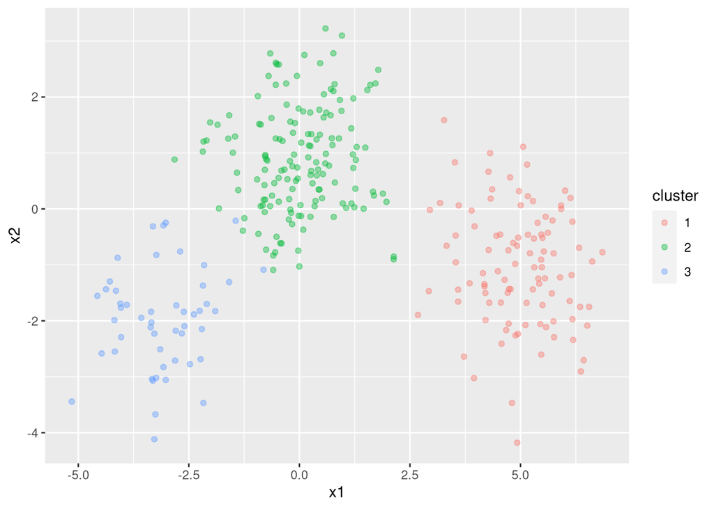

```r
#Simulate the data by passing n and mean to rnorm using map2()
#map2 is using two objects to create a map
# in this case, it is passing the arguments (num_points and x1 or x2 to rnorm)

labelled_pts <-
  cents %>%
  mutate(
    x1 = map2(num_points, x1, rnorm),
    x2 = map2(num_points, x2, rnorm)
  ) %>%
  select(-num_points) %>%
           unnest(cols=c(x1, x2))

ggplot(labelled_pts, aes(x1, x2, color = cluster)) +
  geom_point(alpha = 0.4)
```

```r
points <-
  labelled_pts %>%
  select(-cluster)

kclust <- kmeans(points, centers = 3, n = 25)
kclust
```

```
## K-means clustering with 3 clusters of sizes 48, 100, 152
##
## Cluster means:
##             x1         x2
## 1 -3.194015379 -2.0272690
## 2  4.962808900 -1.0254665
## 3 -0.004476705  0.8627456
##
## Clustering vector:
##   [1] 2 2 2 2 2 2 2 2 2 2 2 2 2 2 2 2 2 2 2 2 2 2 2 2 2 2 2 2 2 2 2 2 2 2 2 2 2
##  [38] 2 2 2 2 2 2 2 2 2 2 2 2 2 2 2 2 2 2 2 2 2 2 2 2 2 2 2 2 2 2 2 2 2 2 2 2 2
##  [75] 2 2 2 2 2 2 2 2 2 2 2 2 2 2 2 2 2 2 2 2 2 2 2 2 2 2 3 3 3 3 3 3 3 3 3 3 3
## [112] 3 3 3 3 3 3 3 3 3 3 3 3 3 3 3 3 3 3 3 3 3 3 3 3 3 3 3 3 3 3 3 3 3 3 3 3 3
## [149] 3 3 3 3 3 3 3 3 3 3 3 3 3 3 3 3 3 3 3 3 3 3 3 3 3 3 3 3 3 3 3 3 3 3 3 3 3
## [186] 3 3 3 3 3 3 3 3 3 3 3 3 3 3 3 3 3 3 3 3 3 3 3 3 3 3 3 3 3 3 3 3 3 3 3 3 3
## [223] 3 3 3 3 3 3 3 3 3 3 3 3 3 3 3 3 3 3 3 3 3 3 3 3 3 3 3 3 1 1 1 1 1 1 1 1 1
## [260] 1 1 1 3 1 3 1 1 1 1 1 1 1 1 1 1 1 1 1 1 1 1 1 1 1 1 1 1 1 1 1 1 1 1 1 1 1
## [297] 1 1 1 1
##
## Within cluster sum of squares by cluster:
## [1]  66.89755 195.90406 277.61532
##  (between_SS / total_SS =  84.6 %)
##
## Available components:
##
## [1] "cluster"      "centers"      "totss"        "withinss"     "tot.withinss"
## [6] "betweenss"    "size"         "iter"         "ifault"
```

```r
#reduces the output sensitivity
#best practices for finding the best n?: maybe tuning or a interative process but we dont know yet
```

```r
#now let's try a systematic method for setting k
#this is more like tuning since we are trying to find optimal number for k

kclusts <-
  tibble(k = 1:9) %>%
  mutate(kclust = map(k, ~kmeans(points, .x)), #not taking two separate objects  .x is where k will be passed to. reading in a single list of k values
         augmented = map(kclust, augment, points)
  )

#we produced a list, but did not do any unnesting yet
```

```r
#append cluster assignment to tibble
assignments <- kclusts %>%
  unnest(cols = c(augmented))

#unnest and what it does. Before it is 'nested' because it is a list and we cant see it. but we unnest to see what is in that column
```

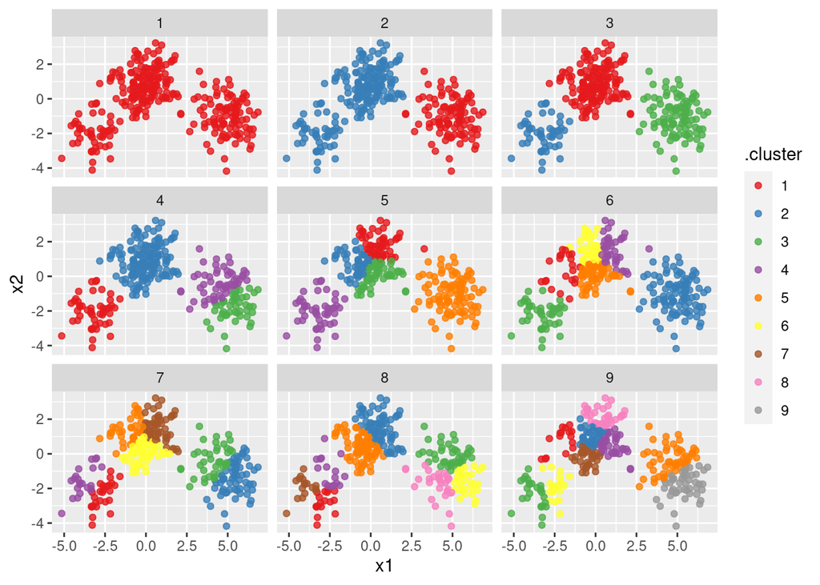

```r
#Plot each model
#can color each point by what cluster they are in because we have already coded for that
p1 <-
  ggplot(assignments, aes(x = x1, y = x2)) +
  geom_point(aes(color = .cluster), alpha = 0.8) +
  scale_color_brewer(palette = "Set1") +
  facet_wrap(~k)

p1
```

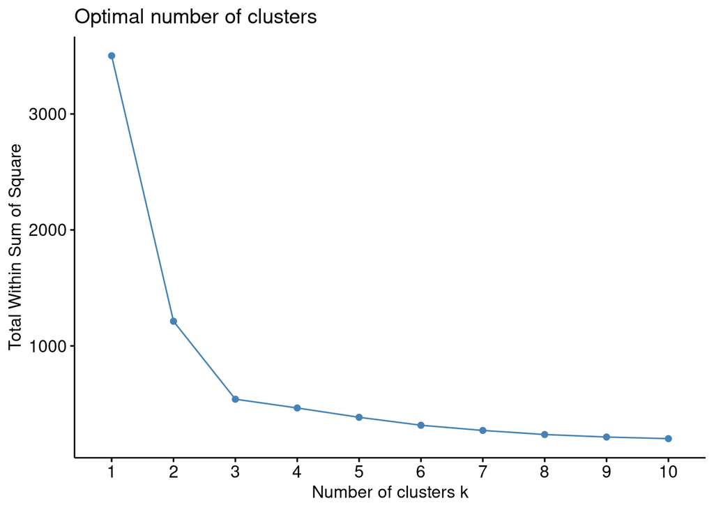

```r
#Use a clustering function from {factoextra} to plot  total WSSs
#doing a shortcut of examining the range of k

fviz_nbclust(points, kmeans, "wss") #wss is a default number of times it will run
```

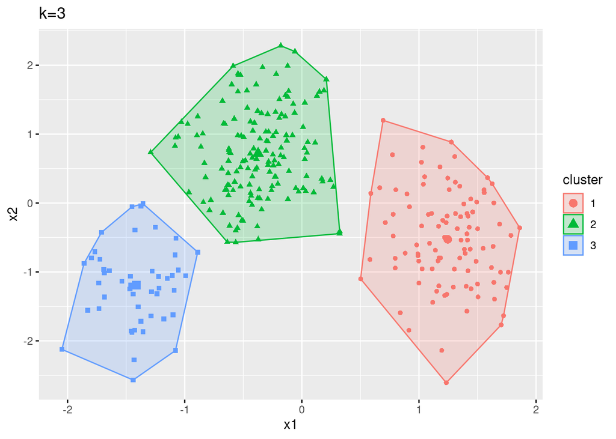

```r
#Another plotting method

k3 <- kmeans(points, centers = 3, nstart = 25)

p3 <- fviz_cluster(k3, geom = "point", data = points) +
  ggtitle("k=3")

p3
```

## In-class assignment!

Now it’s your turn to partition a dataset. For this round we’ll use data from Roberts et al. 2008 on bio-contaminants in Sydney Australia’s Port Jackson Bay. The data are measurements of metal content in two types of co-occurring algae at 10 sample sites around the bay.

```r
#Read in data
metals_dat <- readr::read_csv(here::here("week_8/data/Harbour_metals.csv"))

# Inspect the data
#View(metals_dat)

#Grab pollutant variables
metals_dat2 <- metals_dat[, 4:8]
```

1. Start with k-means clustering - kmeans(). You can start with fviz_nbclust() to identify the best value of k. Then plot the model you obtain with the optimal value of k.

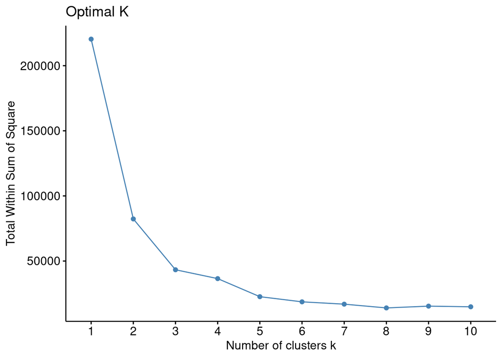

```r
# km_metal <- kmeans(metals_dat2, centers = 3, nstart = 25)

#k-means clustering, find with fviz_nbclust() to find most optimal value of k
km_plot <- fviz_nbclust(metals_dat2, kmeans, "wss") +
  ggtitle("Optimal K")

#plot the cluster line graph
km_plot
```

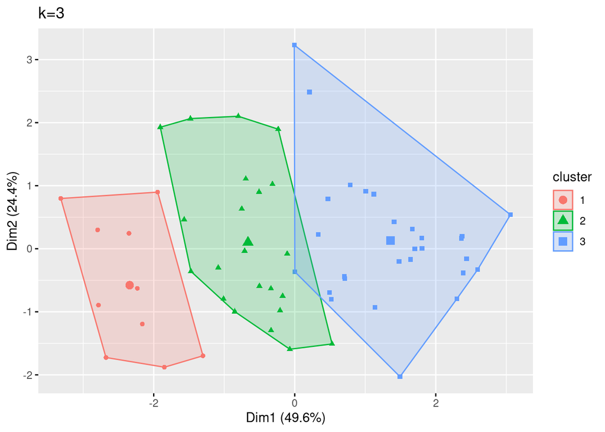

```r
#there are techically two Ks, 3 or 5

#another way to visualize
k3 <- kmeans(metals_dat2, centers = 3, nstart = 25)
k5 <- kmeans(metals_dat2, centers = 5, nstart = 25)

#create the clusters
p3 <- fviz_cluster(k3, geom = "point", data = metals_dat2) +
  ggtitle("k=3")
p5 <- fviz_cluster(k5, geom = "point", data = metals_dat2) +
  ggtitle("k=5")

#print the cluster graphs
p3
```

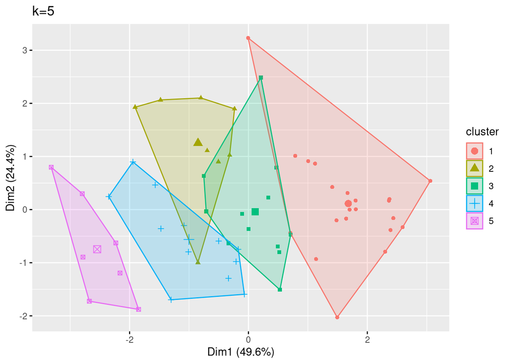

```r
p5
```

Do you notice anything different about the spacing between clusters? Why might this be?

**Answer**: I graphed both clusters that have k = 3 and k = 5. In this case I will focus on k = 3. In this case, when I graphed that spacing between the clusters, I see some of the clusters overlap each other. A couple of the clusters that is related to group 3 can be related to group 2. This is because the data is in 5-D since it has 5 types of columns we are comparing. We are only looking at it in 2-D, meaning that there will be overlap.

Run summary() on your model object. Does anything stand out?

**Answer**: In this questions, I asked Mateo for assistance and he mentioned that we can look at the variable only. I will be doing my analysis of that variable on this section. From this, we see that the Cu and Mn are very different between the three clusters. I can interpret this as the range for these metals in kelp have a very big range. Some kelp samples have low concentrations of those metal while other kelp samples have a large concentration of those metals. All other metals are around the same range, meaning that all kelp have very similar amounts of kelp metal concentration range for all of those.

```r
#look at results for kmeans for k = 3
k3
```

```
## K-means clustering with 3 clusters of sizes 10, 22, 28
##
## Cluster means:
##         Cd       Cr        Cu        Mn    Ni
## 1 0.796000 6.530000 127.09000 126.28200 2.304
## 2 1.076818 6.180455  70.28455  66.79864 2.385
## 3 1.593214 3.462857  22.39893  18.85250 1.870
##
## Clustering vector:
##  [1] 2 2 1 1 1 1 3 2 2 2 2 2 2 2 1 2 2 1 3 3 3 3 3 3 3 3 2 2 2 2 3 3 3 3 3 3 1 3
## [39] 2 3 2 2 3 3 3 3 3 3 2 1 1 2 1 2 2 3 3 3 3 3
##
## Within cluster sum of squares by cluster:
## [1] 13159.695 22633.706  7511.094
##  (between_SS / total_SS =  80.4 %)
##
## Available components:
##
## [1] "cluster"      "centers"      "totss"        "withinss"     "tot.withinss"
## [6] "betweenss"    "size"         "iter"         "ifault"
```

```r
#look at the summary of the k3 model
summary(k3)
```

```
##              Length Class  Mode
## cluster      60     -none- numeric
## centers      15     -none- numeric
## totss         1     -none- numeric
## withinss      3     -none- numeric
## tot.withinss  1     -none- numeric
## betweenss     1     -none- numeric
## size          3     -none- numeric
## iter          1     -none- numeric
## ifault        1     -none- numeric
```

2. Good, now let’s move to hierarchical clustering that we saw in lecture. The first step for that is to calculate a distance matrix on the data (using dist()). Euclidean is a good choice for the distance method.

```r
#find the distance between the datapoint using dist() function
metal_dist <- dist(metals_dat2, method = "euclidean")

#print the distance results
#metal_dist
```

2. Use tidy() on the distance matrix so you can see what is going on. What does each row in the resulting table represent?

```r
#tidy the data into a dataframe
metal_tidy <- tidy(metal_dist)

#View(metal_tidy)
```

3. Then apply hierarchical clustering with hclust().

```r
#use `hclust` to apply hierarchical clustering
metal_hclust <- hclust(metal_dist, method = "complete")

#view the results from hclust
metal_hclust
```

```
##
## Call:
## hclust(d = metal_dist, method = "complete")
##
## Cluster method   : complete
## Distance         : euclidean
## Number of objects: 60
```

4. Now plot the clustering object. You can use something of the form plot(as.dendrogram()). Or you can check out the cool visual options here: https://rpubs.com/gaston/dendrograms

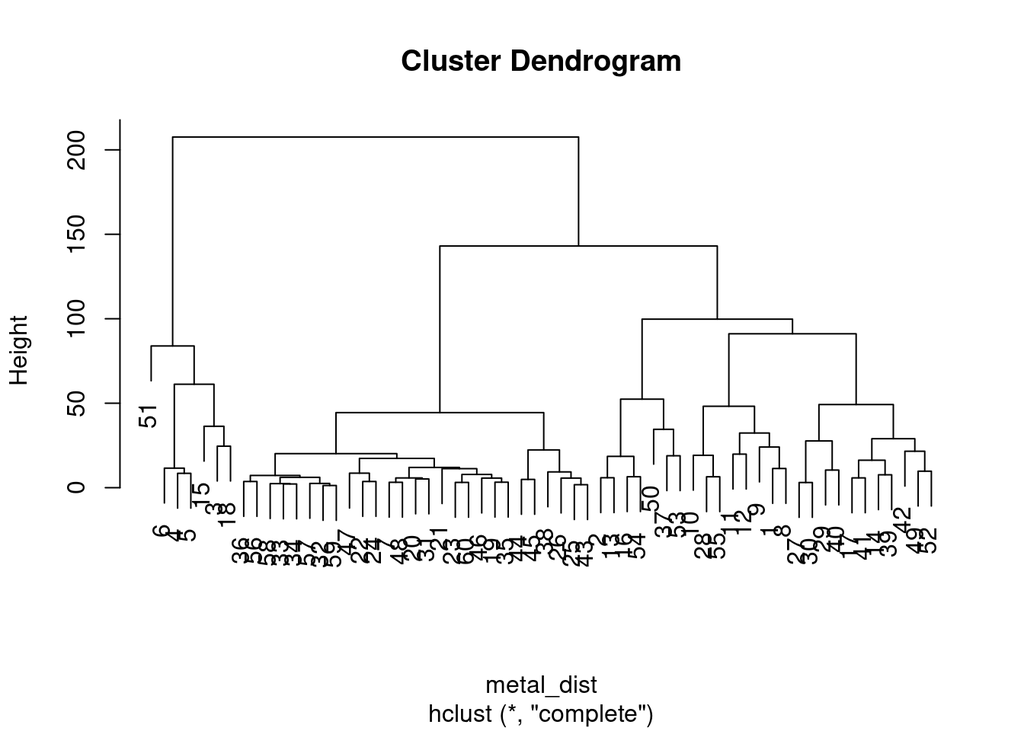

```r
#plot the hcluster with the metal data using as.hclust
plot(as.hclust(metal_hclust))
```

```r
# plot the hcluster with the metal data using as.dendrogram
#plot(as.dendrogram(metal_hclust))

#both show the same thing, just a different way to visualize the content
```

How does the plot look? Do you see any outliers? How can you tell?

**Answer**: The plot looks fairly well grouped. in this plot, there are barely any outliers found on the Dendrogram. If I had to choose any outliers, I would choose observation 51 as it branches off fairly faster than the other observations. I would conclude that observation 51 is a bit different than the other observations and joins the tree ‘later’ than the other observations. All other observations, however, do not look like they are outliers in the dengrogram.